# CENP-N and CENP-C intensity

### Load packages.

Put dependencies at top of script to communicate to others the packages needed for the script to run. You might need to first install ggbeeswarm: install.packages(“ggbeeswarm”). Never include install statements on code you will share with others.

```r
library(tidyverse)
library(ggbeeswarm)
```

## Preliminary: getting data in working order.

### Working with files and directories.

R knows about files in your working directory. If your files are not in this directory, you’ll have to tell R exactly how to find them. Always use relative (not absolute) paths to make it easier for others to reproduce your analysis.

```r
getwd()
```

```
## [1] "D:/2020_R-workshop/src"
```

```r
list.files(path = "../data/", pattern = ".txt", full.names = TRUE)
```

```
## [1] "../data/CENP_intensity_fig1.txt"
## [2] "../data/ch1_RO_nowout_mod.txt"
## [3] "../data/ch1_RO_wout20min_mitotic.txt"
## [4] "../data/ch2_RO_nowout_mod.txt"
## [5] "../data/ch2_RO_wout20min_mitotic.txt"
```

```r
file_in <- "../data/CENP_intensity_fig1.txt"
```

### Import data as a data frame

R will make an educated guess at what kind of information is in each column. For greater control, it’s possible to specify the column types.

```r
df_cenp <- read_delim(file = file_in, delim = "\t", col_names = TRUE)
```

### Check that data meets your expectations.

How many observations are there? Are there missing values? Were columns imported as the correct data type?

```r
df_cenp
```

```
## # A tibble: 2,054 x 13
##    inFile channel cellID count `x-corner` `y-corner`  area  mean   min   max
##    <chr>  <chr>   <chr>  <dbl>      <dbl>      <dbl> <dbl> <dbl> <dbl> <dbl>
##  1 ch1_R~ CENPN   ==pro~     2        164         49    49 1672.   675  5885
##  2 ch1_R~ CENPN   ==pro~     3         96         64    49 1780.   664  6043
##  3 ch1_R~ CENPN   ==pro~     4        192         74    49 1660.   724  4531
##  4 ch1_R~ CENPN   ==pro~     5        169         75    49 1764.   719  7129
##  5 ch1_R~ CENPN   ==pro~     6        158         88    49 1313.   759  3852
##  6 ch1_R~ CENPN   ==pro~     7        149         90    49 1865.   787  6542
##  7 ch1_R~ CENPN   ==pro~     8        130         94    49 1855.   663  6366
##  8 ch1_R~ CENPN   ==pro~     9         79         97    49 1727.   676  6211
##  9 ch1_R~ CENPN   ==pro~    10        164         99    49 2611.   719  9885
## 10 ch1_R~ CENPN   ==pro~    11        108        107    49 1743.   747  5680
## # ... with 2,044 more rows, and 3 more variables: `area*mean` <dbl>,
## #   `area*mean-area*min` <dbl>, `max-min` <dbl>
```

```r
dim(df_cenp)
```

```
## [1] 2054   13
```

```r
typeof(df_cenp$count)
```

```
## [1] "double"
```

### Condition

It would also be nice to have a “condition” variable. This information can be extracted from inFile using string manipulation. See R4DS Chapter 11: Strings with stringr.

```r
df_cenp$inFile[[1]]
```

```
## [1] "ch1_RO_nowout_mod"
```

```r
# a character matrix, access with two indices [[1, 3]], double brackets to  make clear returning a single value
str(str_split(df_cenp$inFile[[1]], "_", simplify = TRUE))
```

```
##  chr [1, 1:4] "ch1" "RO" "nowout" "mod"
```

```r
df_cenp <- df_cenp %>%
  mutate(condition = str_split(inFile, "_", simplify = TRUE)[[1, 3]]) # use 2 indices

df_cenp$condition[[1]]
```

```
## [1] "nowout"
```

### Operation on rows

In this data set, centromere intensity has already been background-subtracted. If this were not the case, we could perform the subtraction ourselves. Here, we’ll recreate the `max-min` and the `area*mean-area*min` variables. Then check for equality.

```r
df_cenp <- df_cenp %>%
  mutate(
    `new_max-min` = max - min,
    `new_area*mean-area*min` = area * mean - area * min
  )

sum(df_cenp[ , "max-min" ] == df_cenp[ , "new_max-min"])
```

```
## [1] 2054
```

```r
nrow(df_cenp)
```

```
## [1] 2054
```

### Selecting columns of interest

If your data set contains columns that are not of interest to you, you can exclude them individually or select the columns you are interested in. The select() function also allows you to rearrange and rename columns in a data frame.

```r
colnames(df_cenp)
```

```
##  [1] "inFile"                 "channel"                "cellID"
##  [4] "count"                  "x-corner"               "y-corner"
##  [7] "area"                   "mean"                   "min"
## [10] "max"                    "area*mean"              "area*mean-area*min"
## [13] "max-min"                "condition"              "new_max-min"
## [16] "new_area*mean-area*min"
```

```r
df_cenp <- df_cenp %>%
  select(condition, channel:cellID, centromere = count, intensity = `area*mean-area*min`)

colnames(df_cenp)
```

```
## [1] "condition"  "channel"    "cellID"     "centromere" "intensity"
```

### Tidy data

See R4DS Chapter 12: Tidy data

```r
df_cenp <- df_cenp %>%
  spread(key = channel, value = intensity)

colnames(df_cenp)
```

```
## [1] "condition"  "cellID"     "centromere" "CENPC"      "CENPN"
```

### Categorical data: convert characters to factor

Categorical variables are those that have a fixed and known set of possible values. What are the advantages of working with factors? See R4DS Chapter 15: Factors

```r
levels(df_cenp$condition)
```

[output not shown]

```r
df_cenp$condition <- as.factor(df_cenp$condition)
levels(df_cenp$condition)
```

```
## [1] "nowout"
```

## Working with the data.

### Exploring the data set.

How many cells does the data represent? How many centromeres per cell? What is the spread of the data? Exploratory data analysis (EDA) is an entire field in itself. See R4DS Chapter 7: Exploratory data analysis.

```r
summary(df_cenp[df_cenp$condition == "nowout", ])
```

```
##   condition       cellID            centromere        CENPC
##  nowout:1027   Length:1027        Min.   : 1.00   Min.   : 17889
##                Class :character   1st Qu.:10.00   1st Qu.:115000
##                Mode  :character   Median :20.00   Median :154977
##                                   Mean   :20.53   Mean   :176667
##                                   3rd Qu.:29.00   3rd Qu.:221181
##                                   Max.   :51.00   Max.   :685278
##      CENPN
##  Min.   :  5774
##  1st Qu.: 43550
##  Median : 65057
##  Mean   : 97719
##  3rd Qu.:134448
##  Max.   :607116
```

```r
summary(df_cenp[df_cenp$condition == "wout20min", ])
```

```
##   condition    cellID            centromere      CENPC         CENPN
##  nowout:0   Length:0           Min.   : NA   Min.   : NA   Min.   : NA
##             Class :character   1st Qu.: NA   1st Qu.: NA   1st Qu.: NA
##             Mode  :character   Median : NA   Median : NA   Median : NA
##                                Mean   :NaN   Mean   :NaN   Mean   :NaN
##                                3rd Qu.: NA   3rd Qu.: NA   3rd Qu.: NA
##                                Max.   : NA   Max.   : NA   Max.   : NA
```

```r
# equivalent to
df_cenp %>%
  filter(condition == "wout20min") %>%
  summary()
```

```
##   condition    cellID            centromere      CENPC         CENPN
##  nowout:0   Length:0           Min.   : NA   Min.   : NA   Min.   : NA
##             Class :character   1st Qu.: NA   1st Qu.: NA   1st Qu.: NA
##             Mode  :character   Median : NA   Median : NA   Median : NA
##                                Mean   :NaN   Mean   :NaN   Mean   :NaN
##                                3rd Qu.: NA   3rd Qu.: NA   3rd Qu.: NA
##                                Max.   : NA   Max.   : NA   Max.   : NA
```

```r
num_cents_by_cellID <- df_cenp %>%
  group_by(condition, cellID) %>%
  summarise(num_cents = n())
num_cents_by_cellID
```

```
## # A tibble: 30 x 3
## # Groups:   condition [1]
##    condition cellID                                                    num_cents
##    <fct>     <chr>                                                         <int>
##  1 nowout    ==proc_RO_nowout_CN-GFP_CC-Y3_CA-Dy649_top-dwn_1.lif - S~        30
##  2 nowout    ==proc_RO_nowout_CN-GFP_CC-Y3_CA-Dy649_top-dwn_1.lif - S~        28
##  3 nowout    ==proc_RO_nowout_CN-GFP_CC-Y3_CA-Dy649_top-dwn_1.lif - S~        28
##  4 nowout    ==proc_RO_nowout_CN-GFP_CC-Y3_CA-Dy649_top-dwn_1.lif - S~        30
##  5 nowout    ==proc_RO_nowout_CN-GFP_CC-Y3_CA-Dy649_top-dwn_1.lif - S~        28
##  6 nowout    ==proc_RO_nowout_CN-GFP_CC-Y3_CA-Dy649_top-dwn_1.lif - S~        24
##  7 nowout    ==proc_RO_nowout_CN-GFP_CC-Y3_CA-Dy649_top-dwn_1.lif - S~        25
##  8 nowout    ==proc_RO_nowout_CN-GFP_CC-Y3_CA-Dy649_top-dwn_1.lif - S~        32
##  9 nowout    ==proc_RO_nowout_CN-GFP_CC-Y3_CA-Dy649_top-dwn_1.lif - S~        24
## 10 nowout    ==proc_RO_nowout_CN-GFP_CC-Y3_CA-Dy649_top-dwn_1.lif - S~        30
## # ... with 20 more rows
```

```r
num_cells_by_condition <- num_cents_by_cellID %>%
  group_by(condition) %>%
  summarise(num_cells = n())
num_cells_by_condition
```

```
## # A tibble: 1 x 2
##   condition num_cells
##   <fct>         <int>
## 1 nowout           30
```

### Plot number of centromeres

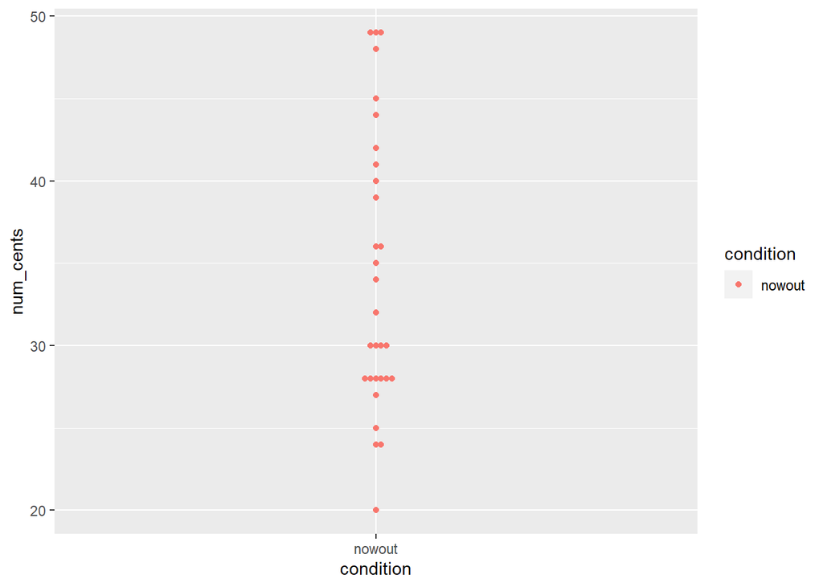

```r
ggplot(data = num_cents_by_cellID, aes(x = condition, y = num_cents)) +
  geom_beeswarm(aes(color = condition))
```

### Plot intensities

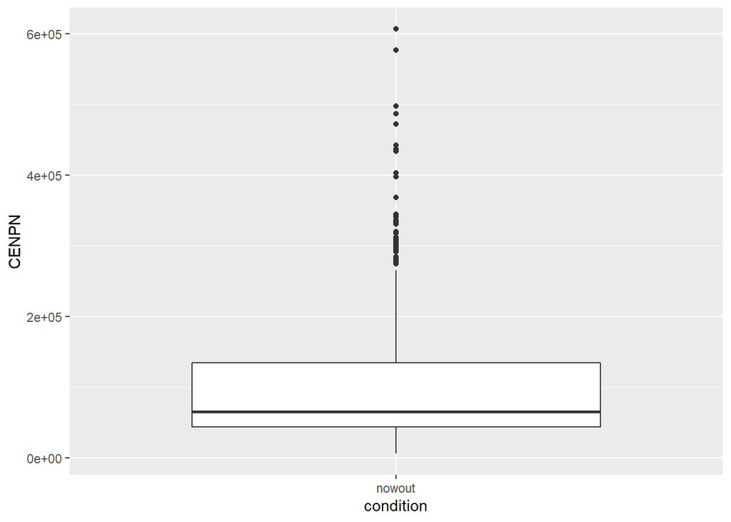

```r
ggplot(data = df_cenp, mapping = aes(x = condition, y = CENPN)) +
  geom_boxplot()
```

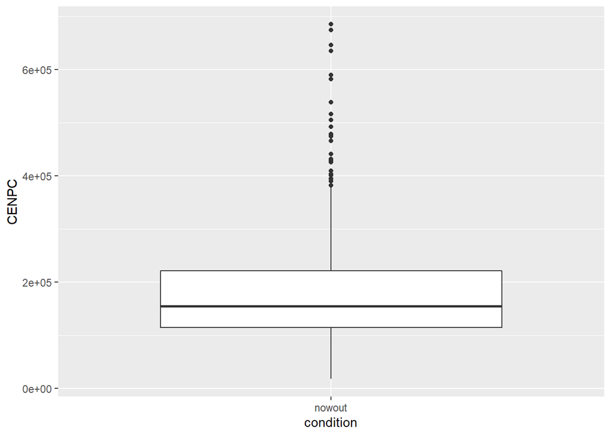

```r
ggplot(data = df_cenp, mapping = aes(x = condition, y = CENPC)) +
  geom_boxplot()
```

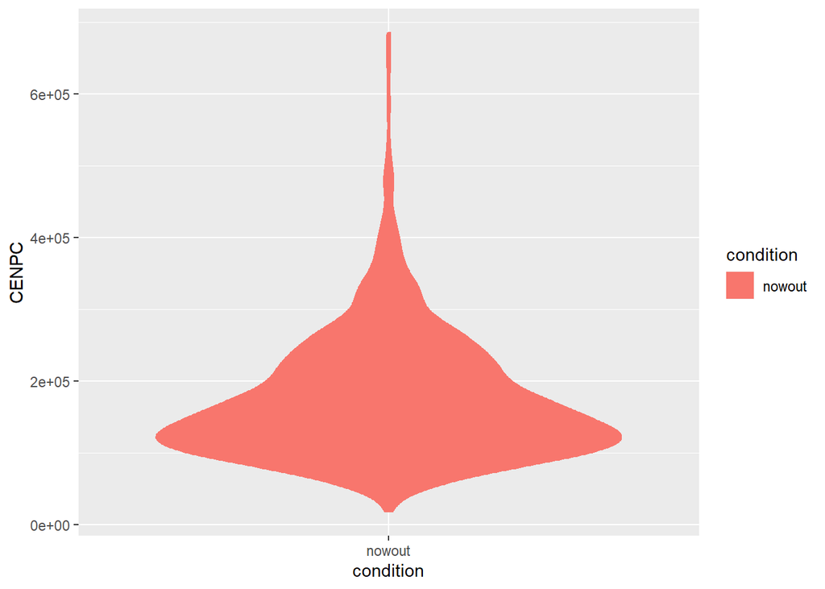

```r
ggplot(data = df_cenp, mapping = aes(x = condition, y = CENPC)) +
  geom_violin(aes(color = condition, fill = condition))
```

### Scale intensity values.

Scale so that average intensity values in the “nowout” condition is 1.

```r
intensity_by_condition <- df_cenp %>%
  group_by(condition) %>%
  summarise(
    num_cents = n(),
    cenpn_mean = mean(CENPN),
    cenpn_sd = sd(CENPN),
    cenpc_mean = mean(CENPC),
    cenpc_sd = sd(CENPC),
    )
df_cenp <- df_cenp %>%
  mutate(
    cenpn_norm = CENPN / (intensity_by_condition[intensity_by_condition$condition == "nowout", ]$cenpn_mean),
    cenpc_norm = CENPC / (intensity_by_condition[intensity_by_condition$condition == "nowout", ]$cenpc_mean)
    )

# It's good to double-check.
 5210/20079 # CENPN
```

```
## [1] 0.2594751
```

```r
21510/24403 # CENPC
```

```
## [1] 0.881449
```

### Summarize scaled intensity values.

Calculate 95% confidence interval from t-distribution. See https://www.cyclismo.org/tutorial/R/confidence.html error <- qt(0.975,df=n-1)*stdev/sqrt(n)

```r
scaled_int_by_condition <- df_cenp %>%
  group_by(condition) %>%
  summarise(
    num_cents = n(),
    cenpn_mean = mean(cenpn_norm),
    cenpn_sd = sd(cenpn_norm),
    cenpc_mean = mean(cenpc_norm),
    cenpc_sd = sd(cenpc_norm)
    ) %>%
  mutate(
    cenpn_error = qt(0.975, df = num_cents-1) * cenpn_sd/sqrt(num_cents),
    cenpn_left =  cenpn_mean - cenpn_error,
    cenpn_right = cenpn_mean + cenpn_error,
    cenpc_error = qt(0.975, df = num_cents-1) * cenpc_sd/sqrt(num_cents),
    cenpc_left =  cenpc_mean - cenpc_error,
    cenpc_right = cenpc_mean + cenpc_error
  )
```

### Plot scaled intensities

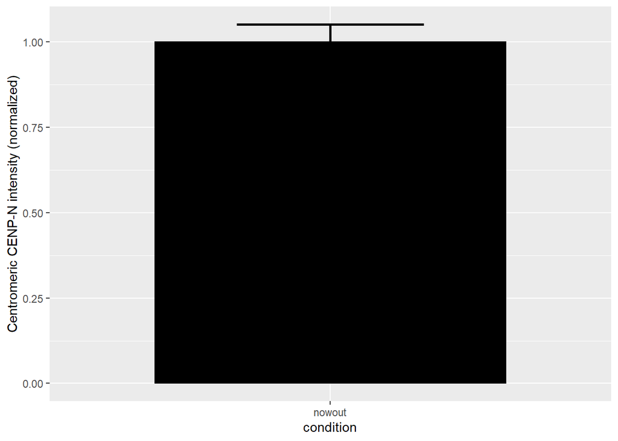

```r
plot_CENPN <- ggplot(data = scaled_int_by_condition) +
  geom_bar(aes(x = condition, y = cenpn_mean), stat = "identity", width = 0.75, colour = "black", fill = "black") +
  geom_errorbar(aes(x = condition, ymin = cenpn_left, ymax = cenpn_right), width = 0.4, size = 1) +
  ylab("Centromeric CENP-N intensity (normalized)")
plot_CENPN
```

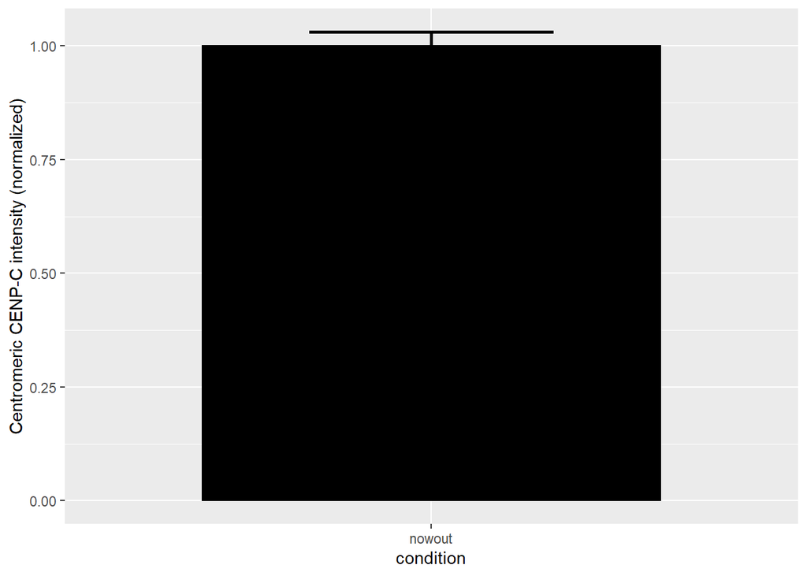

```r
plot_CENPC <- ggplot(data = scaled_int_by_condition) +
  geom_bar(aes(x = condition, y = cenpc_mean), stat = "identity", width = 0.75, colour = "black", fill = "black") +
  geom_errorbar(aes(x = condition, ymin = cenpc_left, ymax = cenpc_right), width = 0.4, size = 1) +
  ylab("Centromeric CENP-C intensity (normalized)")
plot_CENPC
```

### Writing data to file

```r
path_out <- "../results/"

file_stub <- str_split(file_in, "/", simplify = TRUE)[[3]]
file_out <- str_c(path_out, "processed_", file_stub)
file_out
```

```
## [1] "../results/processed_CENP_intensity_fig1.txt"
```

```r
write_tsv(df_cenp, file_out)
```

### Print plot to pdf

Lots of customizations (size, resolution) are possible.

```r
ggsave("../results/ggsave.pdf", plot = plot_CENPC)
```

### Or save as png

Lots of customizations (size, resolution) are possible.

```r
ggsave("../results/ggsave.png", plot = plot_CENPN)
```